# Linear Regression First and Second orders

Author

Affiliation

Undergrad Hernandes Peres

[Biometrics Lab.](https://biometria.ufv.br/)

[figure not shown]

[figure not shown]

# Linear First-Order Regression

Linear regression verify the relation between a dependent variable and one or more independent variables.

In Linear regression, the factor becomes **quantitative**.

$$Y_i=\beta_0+\beta_1X_i+\varepsilon_i$$
To establish a simple linear regression model, the following assumptions must be met:

- The relationship between $X$ and $Y$ is linear.
- The values of $X$ are fixed; in other words, $X$ is not a random variable.
- The mean of the error terms is zero: $E(\varepsilon_i) = 0$.
- For a given value of $X$, the variance of the error terms $\varepsilon_i$ is constant and equal to $\sigma^2$, representing the residual variance. This property is known as homoscedasticity.
- The error terms follow a normal distribution: $\varepsilon_i \sim N(0, \sigma^2)$.

## Example 1: Single Value

The linear model was proposed to explain the relationship between the amount of feed provided and milk production in goats. Using the data below, it is requested to verify whether feed significantly influences milk production (α = 5%).

### 1.1 Computing manually

$$\begin{array}{|c|c|c|c|c|c|}
\hline
\textbf{Feed level (g)} & 50 & 75 & 100 & 125 & 150 \\ \hline
\textbf{Milk production (L/day)} & 1,2 & 1,7 & 2,0 & 2,1 & 2,5 \\
\hline
\end{array}$$

$$\sum_{i=1}^5X_i=500 \quad \sum_{i=1}^5X_i^2=56.250,00 \quad \sum_{i=1}^5X_iY_i=1.025,00$$
$$\sum_{i=1}^5Y_i=9,50 \quad \sum_{i=1}^5Y^2=18,99 \quad \overline{X}=100 \quad \overline{Y} = 1,90$$

$$\sum_{i=1}^n=n\hat{\beta_0}+\hat{\beta_1}\sum_{i=1}^nX_i \\ 5\hat{\beta_0}+500\hat{\beta_1}=9,50\\$$

```r
x <- c(50, 75, 100, 125, 150)
y <- c(1.2, 1.7, 2.0, 2.1, 2.5)
goat <- data.frame(x, y)
goat
```

```
    x   y
1  50 1.2
2  75 1.7
3 100 2.0
4 125 2.1
5 150 2.5
```

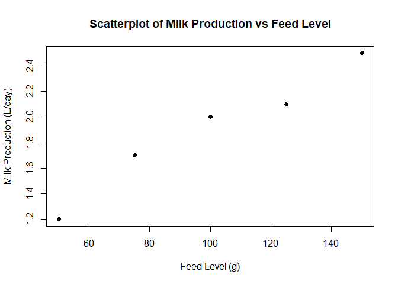

```r
plot(y ~ x, pch = 19, data = goat,
     main = "Scatterplot of Milk Production vs Feed Level",
     xlab = "Feed Level (g)", ylab = "Milk Production (L/day)")
```

```r
cor(goat)
```

```
          x         y
x 1.0000000 0.9784921
y 0.9784921 1.0000000
```

### 1.3 Fitting the linear model

```r
fit1 <- lm(y ~ x)
summary(fit1)
```

```
Call:
lm(formula = y ~ x)

Residuals:
         1          2          3          4          5
-1.000e-01  1.000e-01  1.000e-01 -1.000e-01 -5.204e-17

Coefficients:
            Estimate Std. Error t value Pr(>|t|)
(Intercept) 0.700000   0.154919   4.518  0.02027 *
x           0.012000   0.001461   8.216  0.00377 **
---
Signif. codes:  0 '***' 0.001 '**' 0.01 '*' 0.05 '.' 0.1 ' ' 1

Residual standard error: 0.1155 on 3 degrees of freedom
Multiple R-squared:  0.9574,    Adjusted R-squared:  0.9433
F-statistic:  67.5 on 1 and 3 DF,  p-value: 0.003774
```

```r
anova(fit1)
```

```
Analysis of Variance Table

Response: y
          Df Sum Sq Mean Sq F value   Pr(>F)
x          1   0.90 0.90000    67.5 0.003774 **
Residuals  3   0.04 0.01333
---
Signif. codes:  0 '***' 0.001 '**' 0.01 '*' 0.05 '.' 0.1 ' ' 1
```

```r
fit1$fitted.values
```

```
  1   2   3   4   5
1.3 1.6 1.9 2.2 2.5
```

```r
fit1$res
```

```
           1            2            3            4            5
-1.00000e-01  1.00000e-01  1.00000e-01 -1.00000e-01 -5.20417e-17
```

### 1.4 Checking Normality test

```r
shapiro.test(fit1$res)
```

```
    Shapiro-Wilk normality test

data:  fit1$res
W = 0.82083, p-value = 0.1185
```

Final model **summary** and **statistics**

```r
fit2 <- lm(y ~ x)
summary(fit2)
```

```
Call:
lm(formula = y ~ x)

Residuals:
         1          2          3          4          5
-1.000e-01  1.000e-01  1.000e-01 -1.000e-01 -5.204e-17

Coefficients:
            Estimate Std. Error t value Pr(>|t|)
(Intercept) 0.700000   0.154919   4.518  0.02027 *
x           0.012000   0.001461   8.216  0.00377 **
---
Signif. codes:  0 '***' 0.001 '**' 0.01 '*' 0.05 '.' 0.1 ' ' 1

Residual standard error: 0.1155 on 3 degrees of freedom
Multiple R-squared:  0.9574,    Adjusted R-squared:  0.9433
F-statistic:  67.5 on 1 and 3 DF,  p-value: 0.003774
```

So when we are working with regression, the determination coeffient is use to reffer to how much of the variation is beeing explained by the model. So the coeficient of determination is compute by:

$$r^2=\frac{SQ_{REG}}{SQ_{Total}}100$$

- The inclusion of numerous variables, even if they have very little explanatory power, will increase the value of $r^2$.
- The adjusted $r^2$ penalizes the inclusion of explanatory regressors that contribute very little.

So, we can compute $r_a^2$ by:

$$r_a^2=1-\frac{n-1}{n-k}(1-r^2)$$
**Where:**

- $n:$ is the number of observations;
- $k:$ is number of model parameters;

```r
R2 <- summary(fit2)$adj.r.squared; R2
```

```
[1] 0.9432624
```

```r
anova(fit2)
```

```
Analysis of Variance Table

Response: y
          Df Sum Sq Mean Sq F value   Pr(>F)
x          1   0.90 0.90000    67.5 0.003774 **
Residuals  3   0.04 0.01333
---
Signif. codes:  0 '***' 0.001 '**' 0.01 '*' 0.05 '.' 0.1 ' ' 1
```

```r
coef(fit2)
```

```
(Intercept)           x
      0.700       0.012
```

```r
confint(fit2)
```

```
                 2.5 %     97.5 %
(Intercept) 0.20697754 1.19302246
x           0.00735174 0.01664826
```

### 1.5 Coefficiente of variation (CV)**

$$CV = \frac{\sqrt{QM_{Ind}}}{Y}100$$

```r
QMResid <- anova(fit2)[2, 3]
CV <- 100 * sqrt(QMResid) / mean(y)
CV
```

```
[1] 6.077371
```

### 1.6 Plot - linear regression

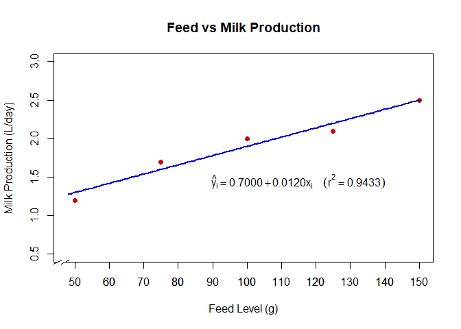

```r
plot(y ~ x, data = goat, pch = 19, col = "red3",
     xlim = c(48, 150), ylim = c(0.5, 3),
     xlab = "Feed Level (g)", ylab = "Milk Production (L/day)",
     main = "Feed vs Milk Production")

axis(1, xaxp = c(50, 150, 10))

# Axis break
require(plotrix)
axis.break(axis = 1, breakpos = 46, bgcol = "white", breakcol = "black",
           style = "slash", brw = 0.02)

# Add regression line
coef.m <- coef(fit2)
curve(coef.m[1] + coef.m[2] * x,
      add = TRUE, lty = 1,
      col = "blue3", lwd = 2)

# Equation and R²
co <- format(c(coef(fit2), R2), digits = 4)
text(115, 1.45,
     label = substitute(hat(y[i]) == b0 + b1 * x[i] ~~~~ (r^2 == r2),
     list(b0 = co[1], b1 = co[2], r2 = co[3])))
```

Ploting with confidence interval

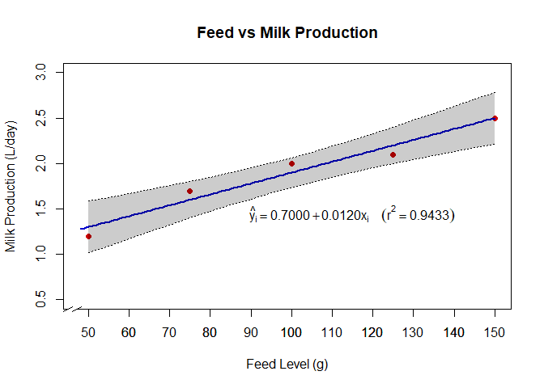

```r
plot(y ~ x, data = goat, pch = 19, col = "red3",
     xlim = c(48, 150), ylim = c(0.5, 3),
     xlab = "Feed Level (g)", ylab = "Milk Production (L/day)",
     main = "Feed vs Milk Production")

axis(1, xaxp = c(50, 150, 10))

require(plotrix)
axis.break(axis = 1, breakpos = 46, bgcol = "white", breakcol = "black",
           style = "slash", brw = 0.02)

curve(coef.m[1] + coef.m[2] * x, add = TRUE, lty = 1, col = "blue3", lwd = 2)

# Confidence intervals
xframe <- data.frame(x = seq(50, 150, by = 5))
xa <- xframe$x
ya <- predict(fit2, int = "c", newdata = xframe)

lines(xa, ya[, "lwr"], lty = 3)
lines(xa, ya[, "upr"], lty = 3)

coord <- data.frame(x = c(xa, rev(xa)), y = c(ya[, "lwr"], rev(ya[, "upr"])))
polygon(coord, border = NA, col = adjustcolor("black", alpha = 0.2))

text(115, 1.45, label = substitute(hat(y[i]) == b0 + b1 * x[i] ~~~~ (r^2 == r2),
                                   list(b0 = co[1], b1 = co[2], r2 = co[3])))
```

## Example 2: With replicates

```r
# Clean environment
rm(list = ls())

# Load data
setwd("C:/StatisticsCourse/11-Regression")
data <- read.table("DataSonifero.txt", header = TRUE)
head(data)
```

```
  x rep  y
1 1   1  3
2 1   2  4
3 1   3  8
4 2   1  5
5 2   2  9
6 2   3 13
```

```r
attach(data)
```

### 2.1 Assumptions checking (CRD)

```r
# Linear model treating x as a qualitative variable
fit1 <- lm(y ~ factor(x))
anova(fit1)
```

```
Analysis of Variance Table

Response: y
          Df Sum Sq Mean Sq F value  Pr(>F)
factor(x)  4    132      33     3.3 0.05721 .
Residuals 10    100      10
---
Signif. codes:  0 '***' 0.001 '**' 0.01 '*' 0.05 '.' 0.1 ' ' 1
```

```r
# Residuals
res <- fit1$residuals
res
```

```
            1             2             3             4             5
-2.000000e+00 -1.000000e+00  3.000000e+00 -4.000000e+00 -2.942091e-15
            6             7             8             9            10
 4.000000e+00 -2.000000e+00  4.996004e-16  2.000000e+00 -4.000000e+00
           11            12            13            14            15
-3.885781e-16  4.000000e+00 -1.000000e+00 -2.000000e+00  3.000000e+00
```

```r
# Normality test
shapiro.test(res)
```

```
    Shapiro-Wilk normality test

data:  res
W = 0.9264, p-value = 0.2409
```

```r
# Homogeneity of variances
bartlett.test(res, x)
```

```
    Bartlett test of homogeneity of variances

data:  res and x
Bartlett's K-squared = 1.1494, df = 4, p-value = 0.8864
```

### 2.2 Regression model (1st-degree)

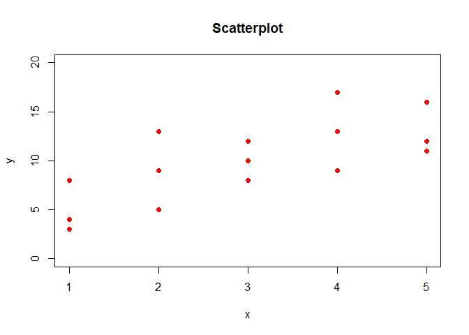

```r
# Scatterplot
plot(x, y, pch = 19, col = "red", ylim = c(0, 20), main = "Scatterplot")
```

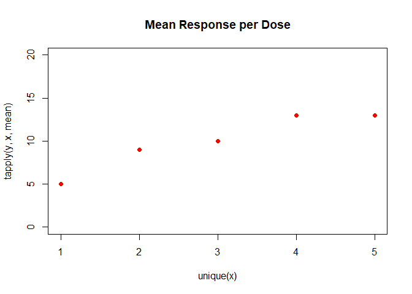

```r
plot(tapply(y, x, mean) ~ unique(x), pch = 19, col = "red", ylim = c(0, 20),
     main = "Mean Response per Dose")
```

### 2.3 Model fitting

```r
fit2 <- lm(y ~ x)
summary(fit2)
```

```
Call:
lm(formula = y ~ x)

Residuals:
   Min     1Q Median     3Q    Max
  -3.0   -2.5    0.0    2.0    5.0

Coefficients:
            Estimate Std. Error t value Pr(>|t|)
(Intercept)   4.0000     1.7774   2.251  0.04237 *
x             2.0000     0.5359   3.732  0.00251 **
---
Signif. codes:  0 '***' 0.001 '**' 0.01 '*' 0.05 '.' 0.1 ' ' 1

Residual standard error: 2.935 on 13 degrees of freedom
Multiple R-squared:  0.5172,    Adjusted R-squared:  0.4801
F-statistic: 13.93 on 1 and 13 DF,  p-value: 0.002512
```

```r
R2 <- summary(fit2)$r.squared; R2
```

```
[1] 0.5172414
```

```r
anova(fit2)
```

```
Analysis of Variance Table

Response: y
          Df Sum Sq Mean Sq F value   Pr(>F)
x          1    120 120.000  13.929 0.002512 **
Residuals 13    112   8.615
---
Signif. codes:  0 '***' 0.001 '**' 0.01 '*' 0.05 '.' 0.1 ' ' 1
```

```r
coef(fit2)
```

```
(Intercept)           x
          4           2
```

```r
confint(fit2)
```

```
                2.5 %   97.5 %
(Intercept) 0.1602680 7.839732
x           0.8422772 3.157723
```

```r
# Fit model treating x as a factor
fit3 <- lm(y ~ factor(x))
summary(fit3)
```

```
Call:
lm(formula = y ~ factor(x))

Residuals:
   Min     1Q Median     3Q    Max
  -4.0   -2.0    0.0    2.5    4.0

Coefficients:
            Estimate Std. Error t value Pr(>|t|)
(Intercept)    5.000      1.826   2.739   0.0209 *
factor(x)2     4.000      2.582   1.549   0.1524
factor(x)3     5.000      2.582   1.936   0.0816 .
factor(x)4     8.000      2.582   3.098   0.0113 *
factor(x)5     8.000      2.582   3.098   0.0113 *
---
Signif. codes:  0 '***' 0.001 '**' 0.01 '*' 0.05 '.' 0.1 ' ' 1

Residual standard error: 3.162 on 10 degrees of freedom
Multiple R-squared:  0.569, Adjusted R-squared:  0.3966
F-statistic:   3.3 on 4 and 10 DF,  p-value: 0.05721
```

```r
R2max <- summary(fit3)$r.squared; R2max
```

```
[1] 0.5689655
```

```r
anova(fit3)
```

```
Analysis of Variance Table

Response: y
          Df Sum Sq Mean Sq F value  Pr(>F)
factor(x)  4    132      33     3.3 0.05721 .
Residuals 10    100      10
---
Signif. codes:  0 '***' 0.001 '**' 0.01 '*' 0.05 '.' 0.1 ' ' 1
```

```r
# Lack of fit test
anova(fit2, fit3)
```

```
Analysis of Variance Table

Model 1: y ~ x
Model 2: y ~ factor(x)
  Res.Df RSS Df Sum of Sq   F Pr(>F)
1     13 112
2     10 100  3        12 0.4 0.7561
```

Interpretation:

Total residual sum of squares (RSS) = 112 Pure error = 100 Lack of fit = 12 (df = 3, F = 0.4, p = 0.7561) Not significant → model fits well

```r
# Real R-squared
r2real <- R2 / R2max
r2real
```

```
[1] 0.9090909
```

```r
library(ExpDes.pt)
# Quantitative data (quali = FALSE)
dic(x, y, quali = FALSE, mcomp = "tukey", sigT = 0.05, sigF = 0.06)
```

```
------------------------------------------------------------------------
Quadro da analise de variancia
------------------------------------------------------------------------
           GL  SQ QM  Fc    Pr>Fc
Tratamento  4 132 33 3.3 0.057205
Residuo    10 100 10
Total      14 232
------------------------------------------------------------------------
CV = 31.62 %

------------------------------------------------------------------------
Teste de normalidade dos residuos ( Shapiro-Wilk )
Valor-p:  0.2409348
De acordo com o teste de Shapiro-Wilk a 5% de significancia, os residuos podem ser considerados normais.
------------------------------------------------------------------------

------------------------------------------------------------------------
Teste de homogeneidade de variancia
valor-p:  0.886359
De acordo com o teste de bartlett a 5% de significancia, as variancias podem ser consideradas homogeneas.
------------------------------------------------------------------------

Ajuste de modelos polinomiais de regressao
------------------------------------------------------------------------

Modelo Linear
========================================
   Estimativa Erro.padrao   tc   valor.p
----------------------------------------
b0     4        1.9148    2.0889 0.0632
b1     2        0.5774    3.4641 0.0061
----------------------------------------

R2 do modelo linear
--------
0.909091
--------

Analise de variancia do modelo linear
===========================================
```

[output cut: 44 more lines]

```
--------
0.967532
--------

Analise de variancia do modelo cubico
==================================================
                     GL   SQ     QM    Fc  valor.p
--------------------------------------------------
Efeito linear        1   120    120    12  0.00608
Efeito quadratico    1  7.7143 7.7143 0.77 0.40039
Efeito cubico        1    0      0     0      1
Desvios de Regressao 1  4.2857 4.2857 0.43 0.52746
Residuos             10  100     10
--------------------------------------------------
------------------------------------------------------------------------
```

### Polynomial regression via reg.poly

```r
# Get ANOVA info
dic <- lm(y ~ factor(x))
anova(dic)
```

```
Analysis of Variance Table

Response: y
          Df Sum Sq Mean Sq F value  Pr(>F)
factor(x)  4    132      33     3.3 0.05721 .
Residuals 10    100      10
---
Signif. codes:  0 '***' 0.001 '**' 0.01 '*' 0.05 '.' 0.1 ' ' 1
```

```r
# Apply polynomial regression
reg.poly(y, x, 10, 100, 4, 132)
```

```
Ajuste de modelos polinomiais de regressao
------------------------------------------------------------------------

Modelo Linear
========================================
   Estimativa Erro.padrao   tc   valor.p
----------------------------------------
b0     4        1.9148    2.0889 0.0632
b1     2        0.5774    3.4641 0.0061
----------------------------------------

R2 do modelo linear
--------
0.909091
--------

Analise de variancia do modelo linear
===========================================
                     GL SQ  QM  Fc  valor.p
-------------------------------------------
Efeito linear        1  120 120 12  0.00608
Desvios de Regressao 3  12   4  0.4 0.75608
Residuos             10 100 10
-------------------------------------------
------------------------------------------------------------------------

Modelo quadratico
=========================================
   Estimativa Erro.padrao   tc    valor.p
-----------------------------------------
b0     1        3.9158    0.2554  0.8036
b1   4.5714     2.9841    1.5319  0.1565
b2  -0.4286     0.4880    -0.8783 0.4004
-----------------------------------------

R2 do modelo quadratico
--------
0.967532
--------

```

[output cut: 22 more lines]

```
--------
0.967532
--------

Analise de variancia do modelo cubico
==================================================
                     GL   SQ     QM    Fc  valor.p
--------------------------------------------------
Efeito linear        1   120    120    12  0.00608
Efeito quadratico    1  7.7143 7.7143 0.77 0.40039
Efeito cubico        1    0      0     0      1
Desvios de Regressao 1  4.2857 4.2857 0.43 0.52746
Residuos             10  100     10
--------------------------------------------------
------------------------------------------------------------------------
```

```
$`Quadro de medias`
    Niveis    Medias Observadas
1        1                    5
2        2                    9
3        3                   10
4        4                   13
5        5                   13

$`Coeficientes reta`
     [,1]
[1,]    4
[2,]    2

$`R2 reta`
[1] 0.9090909

$`Coeficientes parabola`
           [,1]
[1,]  1.0000000
[2,]  4.5714286
[3,] -0.4285714

$`R2 parabola`
[1] 0.9675325

$`Coeficientes cubica`
              [,1]
[1,]  1.000000e+00
[2,]  4.571429e+00
[3,] -4.285714e-01
[4,]  1.251221e-12

$`R2 cubica`
[1] 0.9675325
```

### Regression plot with equation

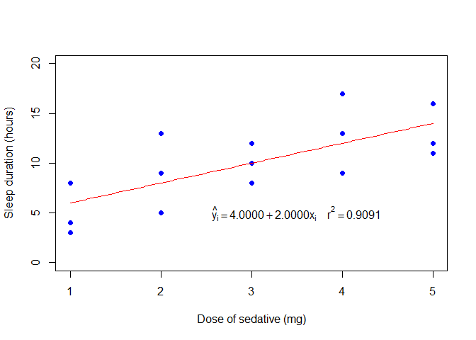

```r
# Plot data points
plot(y ~ x, data = data, pch = 16, col = "blue",
     xlab = "Dose of sedative (mg)", ylab = "Sleep duration (hours)",
     ylim = c(0, 20), frame = FALSE)

# Add regression line
cf.m <- coef(fit2)
curve(cf.m[1] + cf.m[2]*x, add = TRUE, col = "red", lty = 1)

# Annotate with equation and R²
co <- format(c(coef(fit2), r2real), digits = 4)
text(3.5, 5.0,
     label = substitute(hat(y[i]) == b0 + b1*x[i] ~~~~ r^2 == r2,
                        list(b0 = co[1], b1 = co[2], r2 = co[3])))
box()
```

### Fitting with mean and totals

```r
# Using mean values
y1 <- c(5, 9, 10, 13, 13)
x1 <- c(1, 2, 3, 4, 5)
fit5 <- lm(y1 ~ x1)
summary(fit5)
```

```
Call:
lm(formula = y1 ~ x1)

Residuals:
         1          2          3          4          5
-1.000e+00  1.000e+00 -5.551e-16  1.000e+00 -1.000e+00

Coefficients:
            Estimate Std. Error t value Pr(>|t|)
(Intercept)   4.0000     1.2111   3.303   0.0456 *
x1            2.0000     0.3651   5.477   0.0120 *
---
Signif. codes:  0 '***' 0.001 '**' 0.01 '*' 0.05 '.' 0.1 ' ' 1

Residual standard error: 1.155 on 3 degrees of freedom
Multiple R-squared:  0.9091,    Adjusted R-squared:  0.8788
F-statistic:    30 on 1 and 3 DF,  p-value: 0.01197
```

```r
anova(fit5)
```

```
Analysis of Variance Table

Response: y1
          Df Sum Sq Mean Sq F value  Pr(>F)
x1         1     40  40.000      30 0.01197 *
Residuals  3      4   1.333
---
Signif. codes:  0 '***' 0.001 '**' 0.01 '*' 0.05 '.' 0.1 ' ' 1
```

```r
# Using total values
y2 <- c(15, 27, 30, 39, 39)
x2 <- c(1, 2, 3, 4, 5)
fit6 <- lm(y2 ~ x2)
summary(fit6)
```

```
Call:
lm(formula = y2 ~ x2)

Residuals:
         1          2          3          4          5
-3.000e+00  3.000e+00 -7.772e-16  3.000e+00 -3.000e+00

Coefficients:
            Estimate Std. Error t value Pr(>|t|)
(Intercept)   12.000      3.633   3.303   0.0456 *
x2             6.000      1.095   5.477   0.0120 *
---
Signif. codes:  0 '***' 0.001 '**' 0.01 '*' 0.05 '.' 0.1 ' ' 1

Residual standard error: 3.464 on 3 degrees of freedom
Multiple R-squared:  0.9091,    Adjusted R-squared:  0.8788
F-statistic:    30 on 1 and 3 DF,  p-value: 0.01197
```

```r
anova(fit6)
```

```
Analysis of Variance Table

Response: y2
          Df Sum Sq Mean Sq F value  Pr(>F)
x2         1    360     360      30 0.01197 *
Residuals  3     36      12
---
Signif. codes:  0 '***' 0.001 '**' 0.01 '*' 0.05 '.' 0.1 ' ' 1
```

# Linear Second-Order Regression

## Example 3: Single values

A degree-p polynomial function can be represented as:
$$y=\beta_0+\beta_1X^1+\beta_2X^2+...+\beta_pX^p+\varepsilon$$
“According to the data provided below for variable X (Zn micronutrient dose in ppm) and variable Y (dry matter in g/plant), check—using a 5% probability level and a second-degree linear model—whether the relationship between variable X (independent) and Y (dependent) is significant.

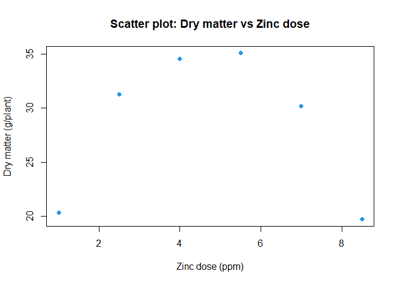

```r
rm(list=ls())  # Remove all created objects

x <- c(1.0, 2.5, 4.0, 5.5, 7.0, 8.5)
y <- c(20.3, 31.3, 34.6, 35.1, 30.2, 19.7)

ms <- data.frame(x, y)

plot(y ~ x, col = 4, pch = 19, data = ms,
     main = "Scatter plot: Dry matter vs Zinc dose",
     xlab = "Zinc dose (ppm)", ylab = "Dry matter (g/plant)")
```

### 3.1 Model selection

#### Fit first-degree model

```r
fit1 <- lm(y ~ x)
summary(fit1)
```

```
Call:
lm(formula = y ~ x)

Residuals:
     1      2      3      4      5      6
-8.648  2.518  5.984  6.650  1.915 -8.419

Coefficients:
            Estimate Std. Error t value Pr(>|t|)
(Intercept)  29.0581     6.6019   4.402   0.0117 *
x            -0.1105     1.2233  -0.090   0.9324
---
Signif. codes:  0 '***' 0.001 '**' 0.01 '*' 0.05 '.' 0.1 ' ' 1

Residual standard error: 7.676 on 4 degrees of freedom
Multiple R-squared:  0.002035,  Adjusted R-squared:  -0.2475
F-statistic: 0.008156 on 1 and 4 DF,  p-value: 0.9324
```

```r
anova(fit1)
```

```
Analysis of Variance Table

Response: y
          Df  Sum Sq Mean Sq F value Pr(>F)
x          1   0.481   0.481  0.0082 0.9324
Residuals  4 235.693  58.923
```

The first-degree model **does not** adequately explain the variability in y.

#### Fit second-order model

```r
fit3 <- lm(y ~ x + I(x^2))
summary(fit3)
```

```
Call:
lm(formula = y ~ x + I(x^2))

Residuals:
       1        2        3        4        5        6
-0.29643  0.84786 -0.69714 -0.03143  0.24500 -0.06786

Coefficients:
            Estimate Std. Error t value Pr(>|t|)
(Intercept) 11.24222    0.97376   11.54 0.001395 **
x           10.46770    0.47719   21.94 0.000207 ***
I(x^2)      -1.11349    0.04895  -22.75 0.000186 ***
---
Signif. codes:  0 '***' 0.001 '**' 0.01 '*' 0.05 '.' 0.1 ' ' 1

Residual standard error: 0.6729 on 3 degrees of freedom
Multiple R-squared:  0.9942,    Adjusted R-squared:  0.9904
F-statistic: 259.3 on 2 and 3 DF,  p-value: 0.0004362
```

```r
anova_fit3 <- anova(fit3)
print(anova_fit3, digits = 6)
```

```
Analysis of Variance Table

Response: y
          Df   Sum Sq  Mean Sq   F value     Pr(>F)
x          1   0.4806   0.4806   1.06137 0.37869168
I(x^2)     1 234.3344 234.3344 517.53931 0.00018601 ***
Residuals  3   1.3584   0.4528
---
Signif. codes:  0 '***' 0.001 '**' 0.01 '*' 0.05 '.' 0.1 ' ' 1
```

### 3.2 Checking Assumptions

```r
shapiro.test(fit3$res)
```

```
    Shapiro-Wilk normality test

data:  fit3$res
W = 0.97122, p-value = 0.9005
```

### 3.3 Computing R²

```r
R2<- summary(fit3)$r.squared
fit4 <- lm(y~factor(x))
R2max <- summary(fit4)$r.squared
Rreal <- R2/R2max
```

### 3.4 Adjusting a regressition plot

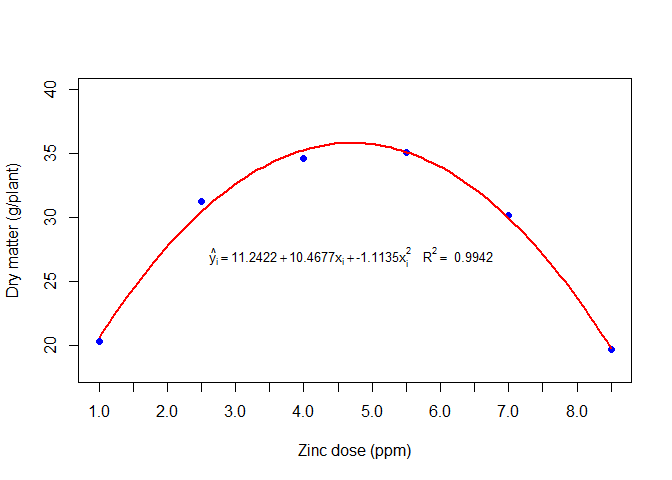

```r
plot(y ~ x, data = ms, pch = 16, col = "blue", xaxt = "n",
     xlab = "Zinc dose (ppm)", ylab = "Dry matter (g/plant)", ylim = c(18, 40))
axis(1, xaxp = c(0, 10, 20))

cf.m4 <- coef(fit3)
curve(cf.m4[1] + cf.m4[2]*x + cf.m4[3]*x^2, add = TRUE, col = "red", lwd = 2)

co <- format(c(coef(fit3), R2), digits = 4)
text(4.7, 27, label = substitute(hat(y[i])==b0+b1*x[i]+b2*x[i]^2~~~~R^2==r2,
                                 list(b0 = co[1], b1 = co[2], b2 = co[3], r2 = co[4])),
     bty = "n", cex = 0.8)
```

## With replicates

```r
# Clear environment
rm(list = ls())
ls()
```

```
character(0)
```

```r
# Load dataset
data <- read.table("DataReagente.txt", header = TRUE)
head(data)
```

```
   x   y
1 50 1.1
2 50 1.3
3 50 1.5
4 75 1.3
5 75 1.6
6 75 1.9
```

```r
attach(data)
```

Assumption checking (CRD)

```r
# Linear model treating x as a factor (for residual analysis)
fit1 <- lm(y ~ factor(x))
res <- fit1$residuals
res
```

```
            1             2             3             4             5
-2.000000e-01  3.070461e-15  2.000000e-01 -3.000000e-01 -8.951173e-16
            6             7             8             9            10
 3.000000e-01 -5.000000e-01  1.000000e-01  4.000000e-01  3.000000e-01
           11            12            13            14            15
-2.000000e-01 -1.000000e-01  4.000000e-01 -1.000000e-01 -3.000000e-01
           16            17            18            19            20
-2.000000e-01 -1.000000e-01  3.000000e-01  2.000000e-01  1.000000e-01
           21            22            23            24            25
-3.000000e-01 -4.000000e-01  1.000000e-01  3.000000e-01 -1.000000e-01
           26            27            28            29            30
 5.000000e-01 -4.000000e-01  7.666667e-01 -3.333333e-01 -4.333333e-01
```

```r
# Normality test
shapiro.test(res)
```

```
    Shapiro-Wilk normality test

data:  res
W = 0.96273, p-value = 0.363
```

```r
# Homogeneity of variances
bartlett.test(res, x)
```

```
    Bartlett test of homogeneity of variances

data:  res and x
Bartlett's K-squared = 4.0582, df = 9, p-value = 0.9075
```

Fitting a quadratic regression model

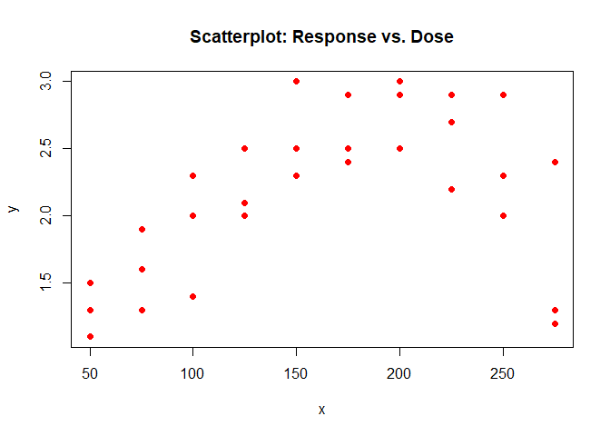

```r
# Scatterplot
plot(x, y, pch = 19, col = "red", main = "Scatterplot: Response vs. Dose")
```

```r
# Quadratic model
fit2 <- lm(y ~ x + I(x^2))
summary(fit2)
```

```
Call:
lm(formula = y ~ x + I(x^2))

Residuals:
     Min       1Q   Median       3Q      Max
-0.67424 -0.26273 -0.03091  0.25295  0.66455

Coefficients:
              Estimate Std. Error t value Pr(>|t|)
(Intercept) -2.774e-01  3.530e-01  -0.786    0.439
x            3.232e-02  4.862e-03   6.649 3.90e-07 ***
I(x^2)      -8.909e-05  1.468e-05  -6.067 1.77e-06 ***
---
Signif. codes:  0 '***' 0.001 '**' 0.01 '*' 0.05 '.' 0.1 ' ' 1

Residual standard error: 0.3653 on 27 degrees of freedom
Multiple R-squared:  0.6493,    Adjusted R-squared:  0.6233
F-statistic: 24.99 on 2 and 27 DF,  p-value: 7.202e-07
```

```r
# Coefficient of determination
R2 <- summary(fit2)$r.squared; R2
```

```
[1] 0.649251
```

```r
anova(fit2)
```

```
Analysis of Variance Table

Response: y
          Df Sum Sq Mean Sq F value    Pr(>F)
x          1 1.7565  1.7565  13.166  0.001172 **
I(x^2)     1 4.9111  4.9111  36.812 1.772e-06 ***
Residuals 27 3.6021  0.1334
---
Signif. codes:  0 '***' 0.001 '**' 0.01 '*' 0.05 '.' 0.1 ' ' 1
```

```r
coef(fit2)
```

```
  (Intercept)             x        I(x^2)
-2.774242e-01  3.232424e-02 -8.909091e-05
```

```r
confint(fit2)
```

```
                    2.5 %        97.5 %
(Intercept) -1.0016465274  4.467980e-01
x            0.0223487758  4.229971e-02
I(x^2)      -0.0001192195 -5.896235e-05
```

$𝑌= −0.2774 + 0.0323𝑋−0.000089𝑋^2$

Residual Sum of Squares = 3.6021 Includes both pure error and lack of fit

### Pure error and lack of fit analysis

```r
# Fit using x as a factor to capture pure error
fit3 <- lm(y ~ factor(x))
summary(fit3)
```

```
Call:
lm(formula = y ~ factor(x))

Residuals:
    Min      1Q  Median      3Q     Max
-0.5000 -0.2750 -0.0500  0.2750  0.7667

Coefficients:
             Estimate Std. Error t value Pr(>|t|)
(Intercept)    1.3000     0.2209   5.886 9.31e-06 ***
factor(x)75    0.3000     0.3123   0.960 0.348275
factor(x)100   0.6000     0.3123   1.921 0.069103 .
factor(x)125   0.9000     0.3123   2.881 0.009227 **
factor(x)150   1.3000     0.3123   4.162 0.000482 ***
factor(x)175   1.3000     0.3123   4.162 0.000482 ***
factor(x)200   1.5000     0.3123   4.802 0.000108 ***
factor(x)225   1.3000     0.3123   4.162 0.000482 ***
factor(x)250   1.1000     0.3123   3.522 0.002144 **
factor(x)275   0.3333     0.3123   1.067 0.298587
---
Signif. codes:  0 '***' 0.001 '**' 0.01 '*' 0.05 '.' 0.1 ' ' 1

Residual standard error: 0.3825 on 20 degrees of freedom
Multiple R-squared:  0.715, Adjusted R-squared:  0.5868
F-statistic: 5.576 on 9 and 20 DF,  p-value: 0.0006799
```

```r
R2max <- summary(fit3)$r.squared; R2max
```

```
[1] 0.7150183
```

```r
anova(fit3)
```

```
Analysis of Variance Table

Response: y
          Df Sum Sq Mean Sq F value    Pr(>F)
factor(x)  9 7.3430 0.81589  5.5756 0.0006799 ***
Residuals 20 2.9267 0.14633
---
Signif. codes:  0 '***' 0.001 '**' 0.01 '*' 0.05 '.' 0.1 ' ' 1
```

```r
# Lack of fit test (comparing quadratic to full model)
anova(fit2, fit3)
```

```
Analysis of Variance Table

Model 1: y ~ x + I(x^2)
Model 2: y ~ factor(x)
  Res.Df    RSS Df Sum of Sq      F Pr(>F)
1     27 3.6021
2     20 2.9267  7   0.67541 0.6594 0.7031
```

```r
anova(fit1, fit2)
```

```
Analysis of Variance Table

Model 1: y ~ factor(x)
Model 2: y ~ x + I(x^2)
  Res.Df    RSS Df Sum of Sq      F Pr(>F)
1     20 2.9267
2     27 3.6021 -7  -0.67541 0.6594 0.7031
```

**Results:**

- RSS (fit2): 3.6021 (27 df)
- Pure Error: 2.9267 (20 df)
- Lack of Fit: 0.6754 (7 df), F = 0.6594, p = 0.7031 → Not significant

```r
# Real R-squared
R2real <- R2 / R2max
R2real
```

```
[1] 0.90802
```

Using ExpDes.pt for Analysis

```r
library(ExpDes.pt)

# Quantitative analysis
dic(x, y, quali = FALSE, mcomp = "tukey", sigT = 0.05, sigF = 0.06)
```

```
------------------------------------------------------------------------
Quadro da analise de variancia
------------------------------------------------------------------------
           GL      SQ      QM     Fc      Pr>Fc
Tratamento  9  7.3430 0.81589 5.5756 0.00067986
Residuo    20  2.9267 0.14633
Total      29 10.2697
------------------------------------------------------------------------
CV = 17.68 %

------------------------------------------------------------------------
Teste de normalidade dos residuos ( Shapiro-Wilk )
Valor-p:  0.3629623
De acordo com o teste de Shapiro-Wilk a 5% de significancia, os residuos podem ser considerados normais.
------------------------------------------------------------------------

------------------------------------------------------------------------
Teste de homogeneidade de variancia
valor-p:  0.9075416
De acordo com o teste de bartlett a 5% de significancia, as variancias podem ser consideradas homogeneas.
------------------------------------------------------------------------

Ajuste de modelos polinomiais de regressao
------------------------------------------------------------------------

Modelo Linear
========================================
   Estimativa Erro.padrao   tc   valor.p
----------------------------------------
b0   1.6158     0.1728    9.3508    0
b1   0.0034     0.0010    3.4646 0.0024
----------------------------------------

R2 do modelo linear
--------
0.239201
--------

Analise de variancia do modelo linear
==================================================
```

[output cut: 44 more lines]

```
--------
0.985354
--------

Analise de variancia do modelo cubico
===================================================
                     GL   SQ     QM    Fc   valor.p
---------------------------------------------------
Efeito linear        1  1.7565 1.7565  12   0.00245
Efeito quadratico    1  4.9111 4.9111 33.56  1e-05
Efeito cubico        1  0.5679 0.5679 3.88  0.06285
Desvios de Regressao 6  0.1076 0.0179 0.12  0.9923
Residuos             20 2.9267 0.1463
---------------------------------------------------
------------------------------------------------------------------------
```

```r
# Polynomial regression with known degrees of freedom and SS
dic <- lm(y ~ factor(x))
anova(dic)
```

```
Analysis of Variance Table

Response: y
          Df Sum Sq Mean Sq F value    Pr(>F)
factor(x)  9 7.3430 0.81589  5.5756 0.0006799 ***
Residuals 20 2.9267 0.14633
---
Signif. codes:  0 '***' 0.001 '**' 0.01 '*' 0.05 '.' 0.1 ' ' 1
```

```r
reg.poly(y, x, 20, 2.9267, 9, 7.3430)
```

```
Ajuste de modelos polinomiais de regressao
------------------------------------------------------------------------

Modelo Linear
========================================
   Estimativa Erro.padrao   tc   valor.p
----------------------------------------
b0   1.6158     0.1728    9.3507    0
b1   0.0034     0.0010    3.4645 0.0024
----------------------------------------

R2 do modelo linear
--------
0.239201
--------

Analise de variancia do modelo linear
==================================================
                     GL   SQ     QM    Fc  valor.p
--------------------------------------------------
Efeito linear        1  1.7565 1.7565  12  0.00245
Desvios de Regressao 8  5.5866 0.6983 4.77 0.00215
Residuos             20 2.9267 0.1463
--------------------------------------------------
------------------------------------------------------------------------

Modelo quadratico
=========================================
   Estimativa Erro.padrao   tc    valor.p
-----------------------------------------
b0  -0.2774     0.3697    -0.7505 0.4617
b1   0.0323     0.0051    6.3483     0
b2  -0.0001     0.00002   -5.7932 0.00001
-----------------------------------------

R2 do modelo quadratico
--------
0.908020
--------

```

[output cut: 22 more lines]

```
--------
0.985354
--------

Analise de variancia do modelo cubico
===================================================
                     GL   SQ     QM    Fc   valor.p
---------------------------------------------------
Efeito linear        1  1.7565 1.7565  12   0.00245
Efeito quadratico    1  4.9111 4.9111 33.56  1e-05
Efeito cubico        1  0.5679 0.5679 3.88  0.06285
Desvios de Regressao 6  0.1076 0.0179 0.12  0.9923
Residuos             20 2.9267 0.1463
---------------------------------------------------
------------------------------------------------------------------------
```

```
$`Quadro de medias`
     Niveis    Medias Observadas
1       100             1.900000
2       125             2.200000
3       150             2.600000
4       175             2.600000
5       200             2.800000
6       225             2.600000
7       250             2.400000
8       275             1.633333
9        50             1.300000
10       75             1.600000

$`Coeficientes reta`
            [,1]
[1,] 1.615757576
[2,] 0.003369697

$`R2 reta`
[1] 0.2392012

$`Coeficientes parabola`
              [,1]
[1,] -2.774242e-01
[2,]  3.232424e-02
[3,] -8.909091e-05

$`R2 parabola`
[1] 0.90802

$`Coeficientes cubica`
              [,1]
[1,]  5.063307e-04
[2,]  2.253371e-02
[3,] -8.029067e-06
[4,] -1.842846e-07

$`R2 cubica`
[1] 0.985354
```

Plotting the Fitted Quadratic Model

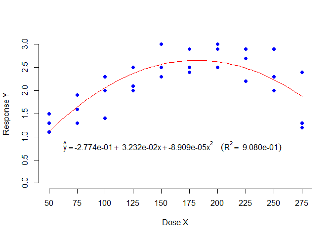

```r
# Plot observed values
plot(y ~ x, data = data, pch = 16, col = "blue",
     xlab = "Dose X", ylab = "Response Y", ylim = c(0, 3),
     xaxt = "n", frame = FALSE)
axis(1, xaxp = c(50, 300, 10))  # custom ticks

# Add fitted curve
cf.m <- coef(fit2)
curve(cf.m[1] + cf.m[2]*x + cf.m[3]*I(x^2), add = TRUE, col = "red", lty = 1)

# Annotate with equation and R²
co <- format(c(coef(fit2), R2real), digits = 4)
text(160, 0.8, label = substitute(
  hat(y) == b0 + b1*x + b2*x^2 ~~~~ (R^2 == r2),
  list(b0 = co[1], b1 = co[2], b2 = co[3], r2 = co[4])))
```